# jekyll-jupyter-notebook20260119-2217-9xhgn

```python
import jax.numpy as jnp
import matplotlib.pyplot as plt
from jax import grad, random, lax
import seaborn as sns

sns.set(font_scale=1.3)
sns.set_style("whitegrid")

sns.set_palette("rocket", n_colors=10)
```

### Train a Linear Perceptron with Gradient Descent

```python
def simulate_lin_reg(N, P, T, eta, sigma = 0.0, seed = 0, inits = 25):

  X = random.normal(random.PRNGKey(seed), (inits, N, P)) # draw random data (inits is # of datasets)

  eps = sigma * random.normal(random.PRNGKey(seed + 1), (inits, P)) # draw random noise

  eps_x = jnp.einsum('ijk,ik->ij', X, eps) / P * jnp.sqrt(N)
  M = jnp.einsum('ijk,ilk->ijl', X,X ) / P  # inits x N x N

  h = jnp.ones((inits, N))

  def update_fn(h,_):
    test_loss = jnp.mean(h**2) + sigma**2

    bias = jnp.mean( h.mean(axis=0)**2 ) + sigma**2

    Delta = 1/jnp.sqrt(N) * jnp.einsum('ijk,ij->ik', X, h) + eps
    train_loss = jnp.mean(Delta**2)
    hp = h - eta * jnp.einsum('ijk,ik->ij', M, h) - eta * eps_x
    return hp, [bias, test_loss, train_loss]

  # trains multiple models simultaneously
  _, losses = lax.scan(update_fn, init = h, xs = None, length = T)

  # bias is error of the average predictor < f >
  bias, test_loss, train_loss = losses

  return bias, test_loss, train_loss
```

## Dynamical Mean Field Theory for the Linear Perceptron (Derive on Board)

We can analyze the proportional limit $P,N \to \infty$ with $P/N=\alpha$ of this problem is given by an evolution of the typical weight discrepancy $v_i(t)$ and training error $\Delta_\mu(t)$ defined as

$$v_i(t) = w^*_i - w_i(t) \ , \ \Delta_\mu(t) = y_\mu - f_\mu(t)$$

In the proportional $P,N \to \infty$ limit, with $\alpha = \frac{P}{N}=\Theta(1)$, we have the following effective stochastic process (derive on the board) for the entries of these vectors

$$\frac{d}{dt} v(t) = \xi_v(t) - \int_0^t ds R_{\Delta}(t,s) v(s) \ , \ \Delta(t) = \xi_{\Delta}(t) - \frac{1}{\alpha} \int_0^t ds R_{v}(t,s) \Delta(s) + \sigma \epsilon$$

where the noise in the labels $\epsilon \sim N(0,1)$ are constant in time and the zero-mean noises $\xi_v(t)$ and $\xi_\Delta(t)$ have the correlations

$$\left< \xi_v(t) \xi_v(s) \right> = \frac{1}{\alpha} C_\Delta(t,s) \equiv \frac{1}{\alpha} \left< \Delta(t) \Delta(s) \right> \ , \ \left< \xi_\Delta(t) \xi_\Delta(s) \right> = C_v(t,s) \equiv \left< v(t) v(s) \right>$$

and the response functions $R_\Delta(t,s)$ and $R_v(t,s)$ have the form

$$R_\Delta(t,s) = \left< \frac{\partial \Delta(t)}{\partial \xi_\Delta(s)} \right> \ , \ R_v(t,s) = \left< \frac{\partial v(t)}{\partial \xi_v(s)} \right> $$

The train loss $\hat{L} (t)$ and test loss $L(t)$ can be computed from the correlation functions

\begin{align} L(t) = C_v(t,t) + \sigma^2 \ , \ \hat{L}(t) = C_\Delta(t,t) \end{align}

```python
# solves DMFT equations for linear perceptron trained with GD
def lin_reg_DMFT(alpha, eta, T, sigma =0.0, steps = 10):

  Theta = eta*jnp.tril( jnp.ones((T,T)), k = -1) # populates lower triangular (integration matrix)

  # initialize response functions at alpha = inf solution
  Rv = jnp.linalg.inv( jnp.eye(T) + Theta ) @ Theta
  R_Delta = jnp.eye(T)

  # update T x T response matrices
  for n in range(steps):
    R_Delta_new = jnp.linalg.inv( jnp.eye(T) + 1.0/alpha * Rv )
    Rv_new = jnp.linalg.inv( jnp.eye(T) + Theta @ R_Delta ) @ Theta
    Rv = 0.8*Rv_new + 0.2 * Rv
    R_Delta = 0.8*R_Delta_new + 0.2*R_Delta

  inv = jnp.linalg.inv( jnp.eye(T) + Theta @ R_Delta )
  Cv = inv @ jnp.ones((T,T)) @ inv.T
  C_Delta = R_Delta @ Cv @ R_Delta.T

  # solve for T x T correlation matrices
  for n in range(steps):
    Cv_new = inv @ ( jnp.ones((T,T)) + 1/alpha * Theta @ C_Delta @ Theta.T ) @ inv.T
    C_Delta_new = R_Delta @ ( Cv + sigma**2 * jnp.ones((T,T)) ) @ R_Delta.T
    Cv = Cv_new
    C_Delta = C_Delta_new

  test_th = jnp.diag( Cv ) + sigma**2
  train_th = jnp.diag( C_Delta )

  return test_th, train_th
```

```python
N = 1500
alpha = 2.0
P = int(alpha * N)
T = 200
eta = 0.05

bias, test, train = simulate_lin_reg(N,P,T,eta)
```

```python
test_DMFT, train_DMFT = lin_reg_DMFT(alpha, eta, T)
```

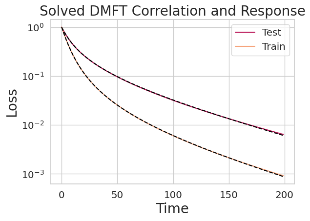

```python
plt.semilogy( test , color = 'C4', label = 'Test ')
plt.semilogy(test_DMFT, '--', color ='black')
plt.semilogy( train, color = 'C8' , label = 'Train' )
plt.semilogy(train_DMFT, '--', color ='black')
plt.xlabel(r'Time',fontsize = 20)
plt.ylabel(r'Loss',fontsize = 20)
plt.title('Solved DMFT Correlation and Response', fontsize = 20)
plt.legend()
plt.tight_layout()
plt.show()
```

## Effect of Overfitting Noise at Interpolation Threshold $\alpha = 1$

```python
alpha = 1.0
N = 2500
P = int(alpha * N)
T = 500
eta = 0.4

sigma_vals = [0.0 , 0.1, 0.25, 0.5, 0.75, 1.0]

all_test , all_train = [] , []
all_test_DMFT , all_train_DMFT = [] , []

for i, sigma in enumerate(sigma_vals):
  test_DMFT, train_DMFT = lin_reg_DMFT(alpha, eta, T, sigma = sigma, steps = 100)

  all_test_DMFT += [test_DMFT]
  all_train_DMFT += [train_DMFT]

  bias, test, train = simulate_lin_reg(N,P,T,eta, sigma = sigma)

  all_test += [test]
  all_train += [train]
```

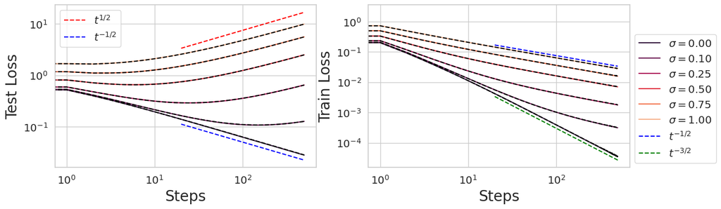

```python
sns.set_palette("rocket", n_colors=len(sigma_vals))

plt.figure(figsize = (14,4))
plt.subplot(1,2,1)
for i, sigma in enumerate(sigma_vals):
  plt.loglog(all_test[i], color = f'C{i}')
  plt.loglog(all_test_DMFT[i], '--', color = f'black')
plt.loglog(jnp.linspace(20,T,T), 0.75*jnp.linspace(20,T,T)**(0.5), '--', color = 'red')
plt.loglog(jnp.linspace(20,T,T), 0.5*jnp.linspace(20,T,T)**(-0.5), '--', color = 'blue')


plt.loglog([],[], '--', color = 'red', label = r'$t^{1/2}$')
plt.loglog([],[], '--', color = 'blue', label = r'$t^{-1/2}$')
plt.legend()


plt.xlabel('Steps',fontsize = 20)
plt.ylabel('Test Loss',fontsize = 20)

plt.subplot(1,2,2)
for i, sigma in enumerate(sigma_vals):
  plt.loglog(all_train[i], color = f'C{i}', label = r'$\sigma = %0.2f$' % sigma)
  plt.loglog(all_train_DMFT[i], '--', color = f'black')


plt.loglog(jnp.linspace(20,T,T), 0.75*jnp.linspace(20,T,T)**(-0.5), '--', color = 'blue',  label = r'$t^{-1/2}$')
plt.loglog(jnp.linspace(20,T,T), 0.3*jnp.linspace(20,T,T)**(-1.5), '--', color = 'green', label = r'$t^{-3/2}$')
plt.xlabel('Steps',fontsize = 20)
plt.ylabel('Train Loss',fontsize = 20)
plt.legend(bbox_to_anchor=(1.0, 0.85), loc='upper left')
plt.show()
```

# Homework Problem 1: Eigenvalue Law from the DMFT Equations

1. Derive the following formulas for the response function by computing derivatives with respect to the Gaussian fields $\xi_v(t)$ and $\xi_\Delta(t)$

$$\partial_t R_v(t,s) = \delta(t-s) - \int_0^t dt' R_{\Delta}(t,t') R_{v}(t',s) \\ R_{\Delta}(t,s) = \delta(t-s) - \frac{1}{\alpha} \int_0^t dt' R_{v}(t,t') R_{\Delta}(t',s)$$

where $\delta(t-s)$ is the Dirac-Delta function.

2. Argue that the solution to these equations should be time-translation invariant (only depend on the time-lag $\tau \equiv t-s$) so that we can write all response functions as functions of a single argument

$$ R_v(t,s) = R_v(t-s) \ , \ R_{\Delta}(t,s) = R_\Delta(t-s)$$

3. Take a Fourier transform of the integro-differential equations and solve for $\mathfrak{R}_\Delta(\omega) = \int_{-\infty}^\infty dt \ e^{-i\omega \tau} R_\Delta(\tau)$ and similarly $\mathfrak{R}_v(\omega) = \int_{-\infty}^\infty dt \ e^{-i\omega \tau} R_v(\tau)$

$$i \omega \mathfrak{R}_v(\omega) = 1 - \mathfrak{R}_\Delta(\omega) \mathfrak{R}_v(\omega) \\ \mathfrak{R}_\Delta(\omega) = 1 - \frac{1}{\alpha} \mathfrak{R}_v(\omega) \mathfrak{R}_\Delta(\omega) $$

4. Solve this system of equations for $\mathfrak{R}_v(\omega)$ (this should be a quadratic equation)

$$\mathfrak{R}_v(\omega) = \frac{\alpha}{2(i\omega)} \left[ -\left(1-\alpha^{-1} + i\omega \right) + \sqrt{\left(1-\alpha^{-1} + i\omega \right)^2 + 4 \alpha^{-1} (i\omega) } \right]$$

(Hint: choose the root that goes as $\mathfrak{R}_v(\omega) \sim \frac{1}{i\omega}$ as $\omega\to \infty$)

5. Using the original dynamics $\frac{d}{dt} v(t) = - M v(t)$ for empirical covariance matrix $M = \frac{1}{P} \sum_{\mu=1}^P x_\mu x_\mu^\top$, argue that $\mathfrak{R}_v(\omega) = \frac{1}{N}\text{Tr}\left[i\omega + M \ \right]^{-1}$ is the resolvent of this matrix. (Hint: Note that we can get the response as $R_v(\tau) = \frac{1}{N} \text{Tr} \frac{\partial v(\tau)}{\partial v(0)^\top } = \frac{1}{N} \text{Tr} \exp\left( - M \tau \right)$. Take a Fourier transform to get the desired result. )
6. Use the Stieltjes transformation to obtain the Marchenko Pastur Law

$$\rho(\lambda) = \frac{1}{\pi} \lim_{\epsilon \to 0} \text{Im} \ \mathfrak{R}_v(\omega)|_{\omega = i\lambda - \epsilon}$$

Hint: First think about the term with the $\sqrt{\cdot}$. This term is imaginary when $4\alpha^{-1} \lambda > (1-\alpha^{-1} - \lambda)^2$ which occurs when (again solve a quadratic equation)

$$\lambda \in [\lambda_{-}, \lambda_+] \ , \ \lambda_{\pm} = \left( 1 \pm \frac{1}{\sqrt \alpha} \right)^2$$

Thus in this interval, we have the bulk density

\begin{align} \rho_{bulk}(\lambda) = \frac{\alpha}{2\pi} \sqrt{ 4\alpha^{-1} \lambda - (1- \alpha^{-1}-\lambda)^2 } \end{align}

Now we note that from the denominator, we also have a term which can potentially go as $\lim_{\epsilon \to 0} \text{Im} \frac{1}{\lambda - i\epsilon} = \pi \delta(\lambda)$. We therefore need to determine the real part that multiplies this term as $\lambda , \epsilon \to 0$. We note that the terms in the brackets cancel out unless $\alpha < 1$ in which case we get the following singular component

$$ \rho_{sing}(\lambda) \sim \lim_{\epsilon \to 0} \text{Im} \frac{\alpha}{2 \pi (- \lambda - i\epsilon) } \left[ (\alpha^{-1} - 1) + \sqrt{ (\alpha^{-1}-1)^2 } \right] = (1-\alpha) \delta(\lambda)$$

We thus obtain the full density

$$\rho(\lambda) = [1-\alpha]_+\delta(\lambda) + \frac{\alpha}{2\pi} \sqrt{ 4\alpha^{-1} \lambda - (1- \alpha^{-1}-\lambda)^2 }$$

# Simulate Test Loss Dynamics with the Random Matrix Eigenvalue Law

```python
def get_eigs(alpha, lamb_grid):
  lambs = jnp.linspace( 0.1/lamb_grid , 6 , lamb_grid )

  lambs = jnp.linspace( 0.1/lamb_grid , 6 , lamb_grid )
  radical = 4*lambs / alpha - (1.0 - 1.0/alpha - lambs)**2
  radical = radical * (radical> 0.0)
  bulk = alpha * jnp.sqrt( radical ) / (2*jnp.pi*lambs)
  return bulk

def lin_reg_RMT(alpha, eta, T, lamb_grid, sigma =0.0):

  lambs = jnp.linspace( 0.6/lamb_grid , 6 , lamb_grid )
  tvals = jnp.linspace(0,T,T)

  radical = 4*lambs / alpha - (1.0 - 1.0/alpha - lambs)**2
  radical = radical * (radical > 0.0)
  bulk = alpha/(2*jnp.pi * lambs) * jnp.sqrt(  radical )

  bulk_dynamics = jnp.exp( - eta * jnp.outer( tvals , lambs) ) @ bulk * jnp.amax(lambs) / lamb_grid
  const_term = (1.0 - alpha) * (1.0 > alpha)

  R = bulk_dynamics + const_term

  test_th = jnp.exp( - 2 * eta * jnp.outer( tvals , lambs) ) @ bulk * jnp.amax(lambs) / lamb_grid  + (1.0 - alpha) * (1.0 > alpha)

  train_th = jnp.exp( - 2 * eta * jnp.outer( tvals , lambs) ) @ (lambs * bulk) * jnp.amax(lambs) / lamb_grid

  return R, test_th, train_th, bulk
```

```python
lamb_grid = 4000 # how many eigenvalues

alpha_vals = [0.25, 0.5, 1.0, 5.0, 10.0, 100.0]
all_bulk = []
for i, alpha in enumerate(alpha_vals):
  bulk = get_eigs(alpha,lamb_grid)
  all_bulk += [bulk]
```

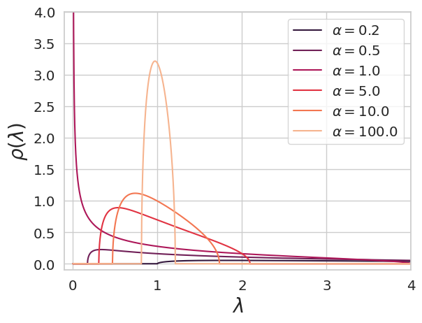

```python
sns.set_palette("rocket", n_colors=len(alpha_vals))

for i, bulk in enumerate(all_bulk):
  lambs = jnp.linspace( 0.1/lamb_grid , 6 , lamb_grid )

  plt.plot(lambs, bulk, label = r'$\alpha = %0.1f$' % alpha_vals[i])

#for i, alpha in enumerate(alpha_vals):
#  if alpha < 1:
    #plt.plot( jnp.zeros(10), jnp.linspace(0, 4.0, 10) , color = f'C{i}')
#plt.plot()
plt.ylim([-0.1,4.0])
plt.xlim([-0.1, 4.0])
plt.xlabel(r'$\lambda$',fontsize =20)
plt.ylabel(r'$\rho(\lambda)$',fontsize =20)

plt.legend()
plt.show()
```

```python
lamb_grid = 4000 # how many eigenvalues
N = 1000
alpha = 2.0
P = int(alpha * N)
T = 250
eta = 0.4

R, test_RMT, train_RMT, bulk = lin_reg_RMT(alpha, eta, T, lamb_grid)
bias, test, train = simulate_lin_reg(N,P,T,eta)
```

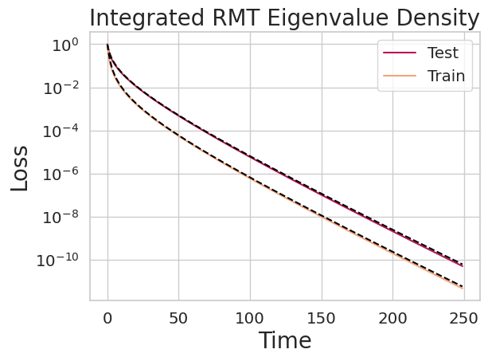

```python
plt.semilogy( test , color = 'C4', label = 'Test ')
plt.semilogy(test_RMT, '--', color ='black')
plt.semilogy( train, color = 'C8' , label = 'Train' )
plt.semilogy(train_RMT, '--', color ='black')
plt.xlabel(r'Time',fontsize = 20)
plt.ylabel(r'Loss',fontsize = 20)
plt.title('Integrated RMT Eigenvalue Density', fontsize = 20)
plt.legend()
plt.tight_layout()
plt.show()
```

```python
alpha_vals = [0.25, 0.5, 0.75, 1.0, 2.5, 5.0]
lamb_grid = 8000
T = 250

eta = 0.05

all_test_RMT = []
all_train_RMT = []
all_test_DMFT = []
all_train_DMFT = []

for i, alpha in enumerate(alpha_vals):
  R, test_RMT, train_RMT, bulk = lin_reg_RMT(alpha, eta, T, lamb_grid)

  all_test_RMT += [test_RMT]
  all_train_RMT  += [train_RMT]

  test_DMFT, train_DMFT = lin_reg_DMFT(alpha, eta, T, steps = 50)
  all_test_DMFT += [test_DMFT]
  all_train_DMFT += [test_DMFT]
```

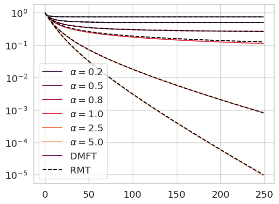

```python
sns.set_palette("rocket", n_colors=len(alpha_vals))
for i, alpha in enumerate(alpha_vals):
  plt.semilogy(all_test_DMFT[i], color = f'C{i}')
  plt.semilogy(all_test_RMT[i], '--', color = 'black')

  plt.semilogy([], [],  color = f'C{i}', label = r'$\alpha = %0.1f$' % alpha)
plt.semilogy([], [], color = 'C1', label = 'DMFT')
plt.semilogy([], [], '--', color = 'black', label = 'RMT')
plt.legend()
plt.show()
```

# Homework Problem 2: Large $t$ Asymptotics of Test Loss

Derive the following large $t$ scalings of the test loss (neglect constant prefactors). Consider first the case where $\sigma^2 = 0$.

### Data Limited Regime (Over-Parameterized) $\alpha < 1$

If $\alpha < 1$, argue that the loss will saturate to a nonzero value due to the null-space of the empirical covariance $\rho(\lambda) = \delta(\lambda)(1-\alpha) + \rho_{bulk}(\lambda)$ so that

$$\lim_{t \to \infty} L(t) = 1-\alpha$$

### Sufficient Data Regime (Under-Parameterized) $\alpha > 1$

If $\alpha > 1$ then argue that the test loss decays exponentially at long times

$$L(t) \sim e^{-2\lambda_{\text{min}} t} \ , \ \lambda_{\text{min}}= \left(1-\frac{1}{\sqrt \alpha} \right)^2$$

### Interpolation Threshold $\alpha = 1$

At $\alpha= 1$, use the Marchenko-Pastur density of eigenvalues

$$\rho(\lambda) = \frac{1}{2\pi} \sqrt{4 \lambda^{-1} - 1} $$ to argue that the model will have a *power law* scaling of the test loss at large $t$ \begin{align} L(t) \sim t^{-1/2} \end{align}

Hint: try a change of variables for the integral $\int d\lambda \ e^{-\lambda t} \rho(\lambda)$ with $\lambda = \frac{u}{t}$. What happens at large $t$?

# Homework problem 2.1 (Optional), Divergence of Loss with Noise

Compute the large $t$ asymptotics at $\alpha=1$ with $\sigma^2 > 0$. Argue that it scales as

$$ L(t) \sim t^{1/2}$$

```python
N = 1500
alpha = 1.0
P = int(alpha * N)
T = 1000
eta = 0.05
lamb_grid = 5000

bias, test, train = simulate_lin_reg(N,P,T,eta)
test_DMFT, train_DMFT = lin_reg_DMFT(alpha, eta, T, steps = 50)
R, test_RMT, train_RMT, bulk = lin_reg_RMT(alpha, eta, T, lamb_grid)

lamb_grid = 12000
_, test_RMT_prec, train_RMT_prec, _ = lin_reg_RMT(alpha, eta, T, lamb_grid)
```

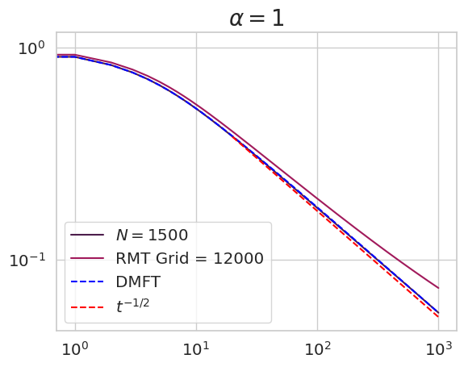

```python
sns.set_palette("rocket", n_colors=4)

plt.loglog(test, label = f'$N = {N}$')
#plt.loglog(test_RMT,label  ='RMT Grid = 5000')
plt.loglog(test_RMT,label  ='RMT Grid = 12000')
plt.loglog(test_DMFT, '--', color = 'blue',label = 'DMFT')
plt.loglog(jnp.linspace(20,T,T), 1.7*jnp.linspace(20,T,T)**(-0.5), '--', color = 'red',label = r'$t^{-1/2}$')
plt.title(r'$\alpha = 1$',fontsize = 20)
plt.legend()
plt.show()
```

# Part II: Regimes of Network Training

In this section, we want to compare the NTK parameterization with the mean field (MF) /$\mu$P parameterization.

Recall that we can modify the last layer of the neural network with a scaling factor.

$$f = \frac{1}{ \gamma_0 N } w^L \cdot \phi(h^L) \ , \ \gamma_0 = \begin{cases} \Theta(N^{-1/2}) & \text{NTK} \\ \Theta(1) & \text{MF} \end{cases} $$

After a finite set of training steps, the kernels $K$ in the network will move by

$$\delta K \sim \Theta\left( \gamma_0^2 \right) = \begin{cases} \Theta(N^{-1}) & \text{NTK} \\ \Theta(1) & \text{MF} \end{cases} $$

Let's implement a CNN with this MF parameterization in Pytorch.

```python
import torch
from torch import nn
import torch.nn.functional as F
from torch.nn import init
import math
import torch.optim as optim
import seaborn as sns
import torchvision
import torchvision.transforms as transforms
import random

import seaborn as sns
import matplotlib.pyplot as plt

sns.set(font_scale=1.3)
sns.set_style("whitegrid")
sns.set_palette("rocket", n_colors=10)


def _calculate_fan_in(tensor):
    dimensions = tensor.dim()
    if dimensions < 2:
        raise ValueError("Fan in and fan out can not be computed for tensor with fewer than 2 dimensions")
    num_input_fmaps = tensor.size(1)
    num_output_fmaps = tensor.size(0)
    receptive_field_size = 1
    if tensor.dim() > 2:
        for s in tensor.shape[2:]:
            receptive_field_size *= s
    fan_in = num_input_fmaps * receptive_field_size
    return fan_in

# unit variance Conv Layer
class Conv_Layer(nn.Module):

  def __init__(self, in_dim, out_dim, kernel_size = 3, stride = 1, padding = 1):

      super().__init__()
      self.conv_layer = nn.Conv2d(in_dim, out_dim, kernel_size, stride, padding, bias = False)
      self.fan_in = _calculate_fan_in(self.conv_layer.weight)

  def forward(self, x):
      return self.conv_layer(x) / math.sqrt( self.fan_in) # 1/sqrt{N} scaling ensures O(1) entries

  def reset_parameters(self) -> None:
      init.normal_(self.conv_layer.weight)


# Simple 3 Layer CNN
class CNN(nn.Module):
    def __init__(self, width, gamma0, num_classes = 10, img_dim = 32):
        super().__init__()

        self.gamma0 = gamma0
        self.width = width
        self.img_dim = img_dim

        self.conv1 = Conv_Layer(3, width)
        self.conv2 = Conv_Layer(width, width)
        self.conv3 = Conv_Layer(width, width)

        final_size =  self.img_dim//8
        self.final_width = int(final_size**2 * self.width)
        self.readout = nn.Linear( self.final_width ,  num_classes, bias = False)

        self.reset_all()


    # initialize weights with O(1) entries
    def reset_all(self) -> None:
        self.conv1.reset_parameters()
        self.conv2.reset_parameters()
        self.conv3.reset_parameters()
        init.normal_(self.readout.weight)


    def forward(self, x):
        x = self.conv1(x)
        x = F.relu(x)
        x = F.max_pool2d(x, 2, 2) # Pooling layer with kernel of 2 and stride of 2
        x = self.conv2(x)
        x = F.relu(x)
        x = F.max_pool2d(x, 2, 2)
        x = self.conv3(x)
        x = F.relu(x)
        x = F.max_pool2d(x, 2,2)
        x = x.view(-1, self.final_width)
        x = 1/(self.gamma0) * self.readout(x) / self.final_width # MF scaling if gamma0 is constant
        return x
```

### Verify that Scale of the Preactivations is Correct

The forward pass entries look like $$h_i^{\ell+1} = \frac{1}{\sqrt N} \sum_{j=1}^N W_{ij}^\ell \phi(h^\ell_j)$$

so we should have constant variance $$ \left< (h_i^{\ell+1})^2 \right> \sim \frac{1}{N} \sum_{j=1}^N \phi(h_j) \phi(h_j) \sim \Theta(1)$$

Let's verify this!

```python
width = 256
model = CNN(width = 256, gamma0 = 0.1)

activation = {}
def get_activation(name):
    def hook(model, input, output):
        activation[name] = output.detach()
        return
    return hook

# extracts hidden variables in forward pass
model.conv1.register_forward_hook(get_activation('layer1'))
model.conv2.register_forward_hook(get_activation('layer2'))
model.conv3.register_forward_hook(get_activation('layer3'))

with torch.no_grad():
  out = model( torch.ones((10,3,32,32)))
```

```
torch.Size([10, 256, 32, 32])
```

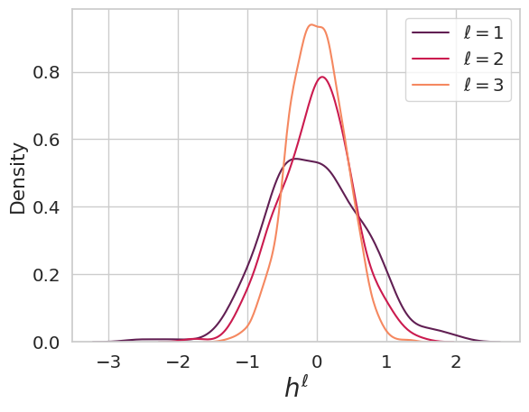

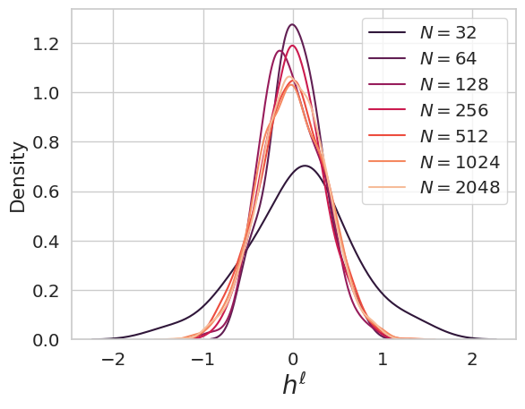

```python
sns.set_palette("rocket", n_colors=3)

print(activation['layer1'].shape)
for l in range(3):
  sns.kdeplot(activation[f'layer{l+1}'][0,:,0,0], label = f'$\ell = {l+1}$')
plt.xlabel(r'$h^{\ell}$',fontsize = 20)
plt.legend()
plt.show()


widths = [32, 64, 128, 256, 512, 1024, 2048]
sns.set_palette("rocket", n_colors=len(widths))


all_acts = []
for i, width in enumerate(widths):
  model = CNN(width = width, gamma0 = 0.1)
  model.conv3.register_forward_hook(get_activation('layer3'))

  with torch.no_grad():
    out = model( torch.ones((10,3,32,32)))
  all_acts += [ activation['layer3'][0,:,0,0] ]

for i,width in enumerate(widths):
  sns.kdeplot(all_acts[i], label = f'$N = {width}$')
plt.xlabel(r'$h^{\ell}$',fontsize = 20)
plt.legend()
plt.show()
```

### Download Simple Image Classification Dataset

```python
import torchvision
import numpy as np
import random
from torchvision import transforms


batch_size = 64
test_batch_size = 512
num_workers = 0


seed = 0
random.seed(seed)
torch.manual_seed(seed)

g = torch.Generator()
g.manual_seed(seed)
np.random.seed(seed)

def seed_worker(worker_id):
    worker_seed = torch.initial_seed() % 2**32
    np.random.seed(worker_seed)
    random.seed(worker_seed)


transform_train = transforms.Compose([
            #transforms.RandomCrop(32, padding=4),
            #transforms.RandomHorizontalFlip(),
            transforms.ToTensor(),
            transforms.Normalize((0.4914, 0.4822, 0.4465), (0.2023, 0.1994, 0.2010)),
        ])

transform_test = transforms.Compose([
      transforms.ToTensor(),
      transforms.Normalize((0.4914, 0.4822, 0.4465), (0.2023, 0.1994, 0.2010)),
])

trainset = torchvision.datasets.CIFAR10(
            root='../dataset', train=True, download=True, transform=transform_train)

trainloader = torch.utils.data.DataLoader(
            trainset, batch_size= batch_size, shuffle=False, generator=g)

testset = torchvision.datasets.CIFAR10(
            root='../dataset', train=False, download=True, transform=transform_test)
testloader = torch.utils.data.DataLoader(
            testset, batch_size = test_batch_size, shuffle=False, generator=g)

classes = ('plane', 'car', 'bird', 'cat', 'deer',
                'dog', 'frog', 'horse', 'ship', 'truck')
```

```
Downloading https://www.cs.toronto.edu/~kriz/cifar-10-python.tar.gz to ../dataset/cifar-10-python.tar.gz
```

```
Extracting ../dataset/cifar-10-python.tar.gz to ../dataset
Files already downloaded and verified
```

```python
lr = 5.0
width = 16
gamma0 = 1.0

model = CNN(width = width, gamma0 = gamma0)

optimizer = optim.SGD(model.parameters(), model.gamma0**2 * model.width * lr, momentum = 0.0)
criterion = nn.CrossEntropyLoss()

device = 'cuda' if torch.cuda.is_available() else 'cpu'
print(device)
model.to(device)

print(model.width)
```

```
cuda
16
```

```python
print([ p.shape for p in model.parameters() ])
```

```
[torch.Size([16, 3, 3, 3]), torch.Size([16, 16, 3, 3]), torch.Size([16, 16, 3, 3]), torch.Size([10, 256])]
```

```python
# training loop with fixed order of the SGD data
# we will do 1 epoch
def train_model(width, lr, gamma0, NTK_p = False, base_width = 64.0):
  train_losses = []
  train_loss = 0
  correct = 0
  total = 0
  counter = 0
  eval_every = 10
  random.seed(0)
  torch.manual_seed(0)
  np.random.seed(0)

  gamma0_model = gamma0

  if NTK_p:
    gamma0_model = gamma0 / math.sqrt( width / base_width ) # coincides with MF at N = base_width

  model = CNN(width = width, gamma0 = gamma0_model)

  optimizer = optim.SGD(model.parameters(), model.gamma0**2 * model.width * lr, momentum = 0.0)
  criterion = nn.CrossEntropyLoss()

  device = 'cuda' if torch.cuda.is_available() else 'cpu'
  model.to(device)

  trainloader = torch.utils.data.DataLoader(
            trainset, batch_size= batch_size, shuffle=False, generator=g)


  for batch_idx, (inputs, targets) in enumerate(trainloader):
      inputs, targets = inputs.to(device), targets.to(device)
      optimizer.zero_grad()
      outputs = model(inputs)
      loss = criterion(outputs, targets)
      loss.backward()
      optimizer.step()
      train_loss += loss.item()
      _, predicted = outputs.max(1)
      total += targets.size(0)
      counter += 1

      if batch_idx % eval_every == 0 and batch_idx > 0:
          train_losses += [train_loss/eval_every]
          train_loss = 0
          counter = 0


  model.conv3.register_forward_hook(get_activation('layer3'))

  for batch_idx, (inputs, targets) in enumerate(testloader):
    with torch.no_grad():
      inputs = inputs.to(device)
      out = model(inputs)
      indsort = np.argsort(targets)
      acts = activation['layer3'][indsort,:,:,:]
      acts = F.relu(acts).mean(axis = (2,3))
      kernel = acts @ acts.T / acts.shape[1]

    break

  return train_losses, kernel.cpu()
```

```python
lr = 5.0
gamma0 = 0.5

widths= [64, 128, 256, 512, 1024, 2048]
all_losses = []
all_kernel = []
for i, width in enumerate(widths):
  print(f"width = {width}")
  loss, kernel = train_model(width , lr , gamma0)
  all_losses += [loss]
  all_kernel += [kernel]
```

```
width = 64
width = 128
width = 256
width = 512
width = 1024
width = 2048
```

```python
widths= [64, 128, 256, 512, 1024, 2048]
all_losses_NTK = []
all_kernel_NTK = []
for i, width in enumerate(widths):
  print(f"width = {width}")
  loss, kernel = train_model(width , lr , gamma0, NTK_p=True)
  all_losses_NTK += [loss]
  all_kernel_NTK += [kernel]
```

```
width = 64
width = 128
width = 256
width = 512
width = 1024
width = 2048
```

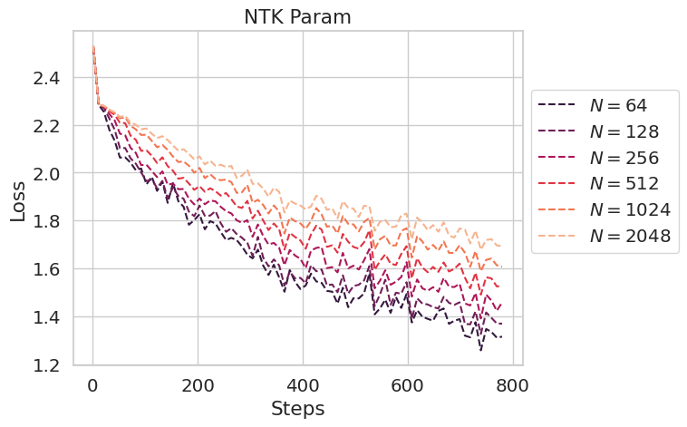

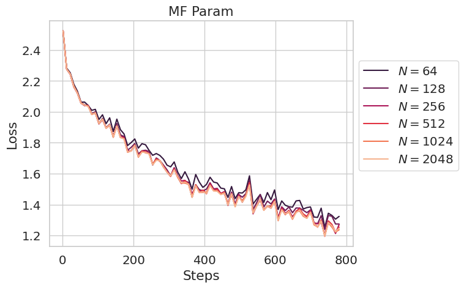

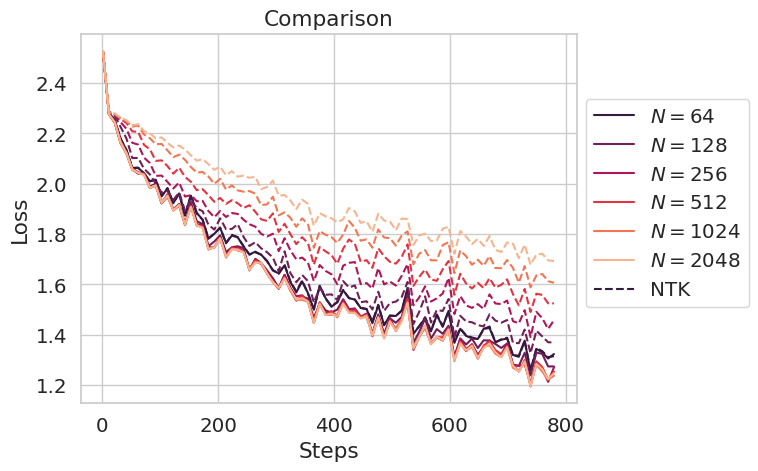

```python
sns.set(font_scale=1.3)
sns.set_style("whitegrid")
sns.set_palette("rocket", n_colors=len(all_losses))

for i, loss in enumerate(all_losses):
  plt.plot(np.linspace(1,10*len(all_losses_NTK[i]), len(all_losses_NTK[i])), all_losses_NTK[i], '--', color = f'C{i}', label = f'$N = {widths[i]}$')
plt.title('NTK Param')
plt.xlabel('Steps')
plt.ylabel('Loss')
plt.legend(bbox_to_anchor=(1.0, 0.85), loc='upper left')
plt.show()

for i, loss in enumerate(all_losses):
  plt.plot(np.linspace(1,10*len(all_losses_NTK[i]), len(all_losses_NTK[i])),loss, color = f'C{i}', label = f'$N = {widths[i]}$')
  #plt.plot(all_losses_NTK[i], '--', color = f'C{i}')
plt.title('MF Param')
plt.xlabel('Steps')
plt.ylabel('Loss')
plt.legend(bbox_to_anchor=(1.0, 0.85), loc='upper left')

plt.show()


for i, loss in enumerate(all_losses):
  plt.plot(np.linspace(1,10*len(all_losses_NTK[i]), len(all_losses_NTK[i])),loss, color = f'C{i}', label = f'$N = {widths[i]}$')
  plt.plot(np.linspace(1,10*len(all_losses_NTK[i]), len(all_losses_NTK[i])),all_losses_NTK[i], '--', color = f'C{i}')

plt.plot([],[], '--', color = 'C0', label = 'NTK')
plt.title('Comparison')
plt.xlabel('Steps')
plt.ylabel('Loss')
plt.legend(bbox_to_anchor=(1.0, 0.85), loc='upper left')

plt.show()
```

```python
random.seed(0)
torch.manual_seed(0)
np.random.seed(0)

all_kernel_init = []

for i, width in enumerate(widths):
  model = CNN(width = width, gamma0 = gamma0)
  model.to(device)
  model.conv3.register_forward_hook(get_activation('layer3'))

  for batch_idx, (inputs, targets) in enumerate(testloader):
    with torch.no_grad():
      inputs = inputs.to(device)
      out = model(inputs)
      indsort = np.argsort(targets)
      acts = activation['layer3'][indsort,:,:,:]
      acts = F.relu(acts).mean(axis = (2,3))
      kernel = acts @ acts.T / acts.shape[1]

    break

  all_kernel_init += [kernel.cpu()]
```

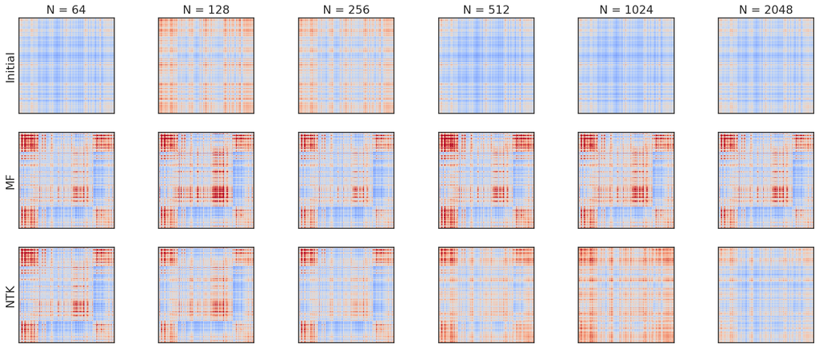

```python
sns.set_style("white")
sns.set_palette("rocket", n_colors=len(all_losses))

vmax = 10.0
plt.figure(figsize = (20, 8))
for i, kernel in enumerate(all_kernel):
  plt.subplot(3, len(all_kernel), i+1)
  plt.imshow(all_kernel_init[i], vmin = 0.0, vmax = 0.05*vmax, cmap = 'coolwarm')
  plt.xticks([])
  plt.yticks([])
  if i == 0:
    plt.ylabel('Initial')
  plt.title(f'N = {widths[i]}')


  plt.subplot(3, len(all_kernel), len(all_kernel)+i+1)
  plt.imshow(kernel, vmin = 0.0, vmax = vmax,  cmap = 'coolwarm')
  if i == 0:
    plt.ylabel('MF')
  plt.xticks([])
  plt.yticks([])

  plt.subplot(3, len(all_kernel), 2*len(all_kernel) + i+1)
  plt.imshow(all_kernel_NTK[i],  vmin = 0.0, vmax = vmax, cmap = 'coolwarm')
  plt.xticks([])
  plt.yticks([])
  if i == 0:
    plt.ylabel('NTK')
plt.show()
```

# Homework Problem 3 (Kernels in Two Layer MF Limit)

1. Consider a two layer neural network

$$f = \frac{1}{\gamma_0 N} \sum_{i=1}^N w^1_i \ \phi( h_i(x) ) \ , \ h_i(x) = \frac{1}{\sqrt D} \sum_{j=1}^D W^0_{ij} x_j$$

When training the parameters $\theta = \{ w^1, W^0 \}$ with gradient flow on a mean square error $L = \frac{1}{P} \sum_{\mu=1}^P (f(x_\mu) - y_\mu)^2$ with learning rate $\eta = \eta_0 \gamma_0^2 N$, show that the evolution of the function is

$$\frac{d}{dt} f(x, t) = - \eta \frac{\partial f}{\partial \theta} \cdot \nabla_{\theta} L = \frac{\eta_0}{P} \sum_{\mu=1}^P K(x, x_\mu, t) (y_\mu - f(x_\mu, t))$$

where the NTK $$K(x,x') = N \gamma_0^2 \sum_{i=1}^N \frac{\partial f(x)}{\partial w_i^1 } \frac{\partial f(x')}{\partial w_i^1 } + N \gamma_0^2 \sum_{i=1}^N \sum_{j=1}^D \frac{\partial f(x)}{\partial W^0_{ij} } \frac{\partial f(x')}{\partial W^0_{ij} }$$ can be expressed as $$K(x,x') = \frac{1}{N} \sum_{i=1}^N \phi(h_i(x)) \phi(h_i(x')) + \frac{1}{N} \sum_{i=1}^N (w^1_i)^2 \dot\phi(h_i(x))\dot\phi(h_i(x')) \times \frac{1}{D} \sum_{j=1}^D x_j x'_j$$

Argue this object is constant in $\Theta_{N, \gamma_0}(1)$ at initialization.

2. Show that the preactivations $h_i(x, t)$ evolve as

$$ \frac{d}{dt} h_i(x,t) = \frac{\eta_0 \gamma_0}{P} w^1_i(t) \sum_{\mu=1}^P (y_\mu - f(x_\mu, t)) \dot\phi(h_i(x_\mu, t)) \left[ \frac{1}{D} x \cdot x_\mu \right]$$

and that the readout weights $w^1_i$ evolve as

$$\frac{d}{dt} w^1_i(t) = \frac{\eta_0\gamma_0}{P} \sum_{\mu=1}^P (y_\mu - f(x_\mu, t)) \phi(h_i(x_\mu, t))$$

3. Show that the above equations imply that if $\gamma_0 \to 0$ that $K(x,x')$ will remain constant.
4. Argue that as $N \to \infty$ that $K(x,x')$ will concentrate (become self-averaging) so that $f(x,t)$ will concentrate. This means that $f$ won't depend on the individual variables $h_i$ or $w_i^1(t)$.
5. Since $f$ doesn't depend on $w_i^1$ or $h_i(x,t)$, argue that all neurons are statistically independent in the $N \to \infty$ limit.